# Microbiome data analysis

Wendy Phillips

1/23/2022

## Microbiome analysis

First load the libraries that will be used.

```r
library(tidyverse)
library(vegan)
library(ape)
library(ALDEx2)
library(cowplot)
library(rstatix)
library(ggpubr)
```

Load data: a taxatable and a metadata table.  
These data are from:  
Zeller et al. (2014): https://doi.org/10.15252/msb.20145645.

```r
genus_table <- read.delim("../data/crc_zeller/crc_zeller_genus_table.tsv", sep = "\t", row.names = 1, check.names = FALSE)

metadata <- read.delim("../data/crc_zeller/crc_zeller_metadata.tsv", sep = "\t", check.names = FALSE)
```

First, modify the sample names to use `_` instead of `-`, since the latter gets converted to a `.` by some functions.

```r
colnames(genus_table) <- gsub("-", "_", colnames(genus_table))
metadata$sampleid <- gsub("-", "_", metadata$sampleid)
```

Change the `._.` in the taxonomy strings to the more commonly used `;`.

```r
rownames(genus_table) <- gsub("\\._.", ";", rownames(genus_table))
```

Also, move the sampleids to be the rownames for the metadata.

```r
metadata <- tibble::column_to_rownames(metadata, "sampleid")
```

Check the column sums of the genus table to see if it has already been normalized.

```r
colSums(genus_table)[1:5]
```

```
## FR_026 FR_027 FR_030 FR_039 FR_040
##  44780  90149  54711  46673  45810
```

Rarefy the count table.  
First check that the sample with the fewest reads still has a reasonable amount of reads.

```r
min_reads <- min(colSums(genus_table))
min_reads
```

```
## [1] 28042
```

For amplicon data, 28042 reads is definitely plenty for a minimum to rarefy to.

```r
# Transpose the dataframe for use with vegan
genus_rarefied_t <- data.frame(vegan::rrarefy(t(genus_table), min(colSums(genus_table))))
```

Look at the row sums again to check the table was rarefied appropriately.

```r
rowSums(genus_rarefied_t)[1:5]
```

```
## FR_026 FR_027 FR_030 FR_039 FR_040
##  28042  28042  28042  28042  28042
```

Remove any genera that now have a count of zero in all samples.

```r
genus_rarefied_t <- genus_rarefied_t[, colSums(genus_rarefied_t) != 0]
```

Now we can calculate some alpha metrics.  
The most basic alpha diversity measure is how many different genera are observed in each sample.

```r
num_genera <- vegan::specnumber(genus_rarefied_t)
```

Next, calculate the Shannon-Wiener diversity index.

```r
shannon <- vegan::diversity(genus_rarefied_t, index = "shannon", MARGIN = 1)
```

Also, the inverse Simpson’s index.

```r
simpson <- vegan::diversity(genus_rarefied_t, index = "invsimpson", MARGIN = 1)
```

And Chao1.

```r
chao1 <- vegan::estimateR(genus_rarefied_t)[2, ]
```

Now combine all those calculated indices into a single dataframe.

```r
alpha_values <- data.frame(Num_genera = num_genera, Chao1 = chao1, Shannon = shannon, Simpson = simpson)
```

Add the metadata category of interest to the alpha_values dataframe.

```r
alpha_values <- merge(metadata, alpha_values, by = 0)
```

Rename the merged column of `Row.names` to b `Sample`.

```r
alpha_values <- alpha_values %>% dplyr::rename("Sample" = "Row.names")
```

Now plots can be made to visualize the results.

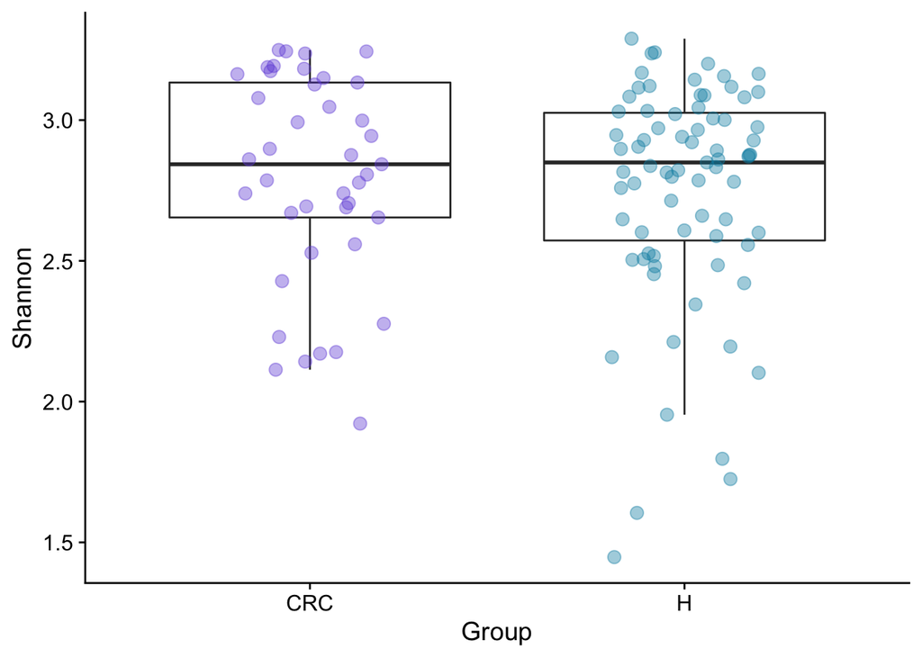

```r
shannon_plot <- ggplot(alpha_values, aes(x = comparison, y = Shannon)) +
  geom_boxplot(outlier.color = NA, lwd = 0.5) +
  theme_cowplot() +
  geom_jitter(size = 3, width = 0.2, alpha = 0.4, aes(color = comparison)) +
  scale_color_manual(values = c("#7153db", "#008eb0")) +
  theme(legend.position = "none") +
  labs(x = "Group")

shannon_plot
```

We could make the above plotting code into function.

```r
alpha_plot <- function(input_table, metric) {
  ggplot(input_table, aes_string(x = "comparison", y = metric)) +
    geom_boxplot(outlier.color = NA, lwd = 0.5) +
    theme_cowplot() +
    geom_jitter(size = 3, width = 0.2, alpha = 0.4, aes(color = comparison)) +
    scale_color_manual(values = c("#7153db", "#008eb0")) +
    theme(legend.position = "none") +
    labs(x = "Group")
}
```

Try the function with one of the alpha metrics.

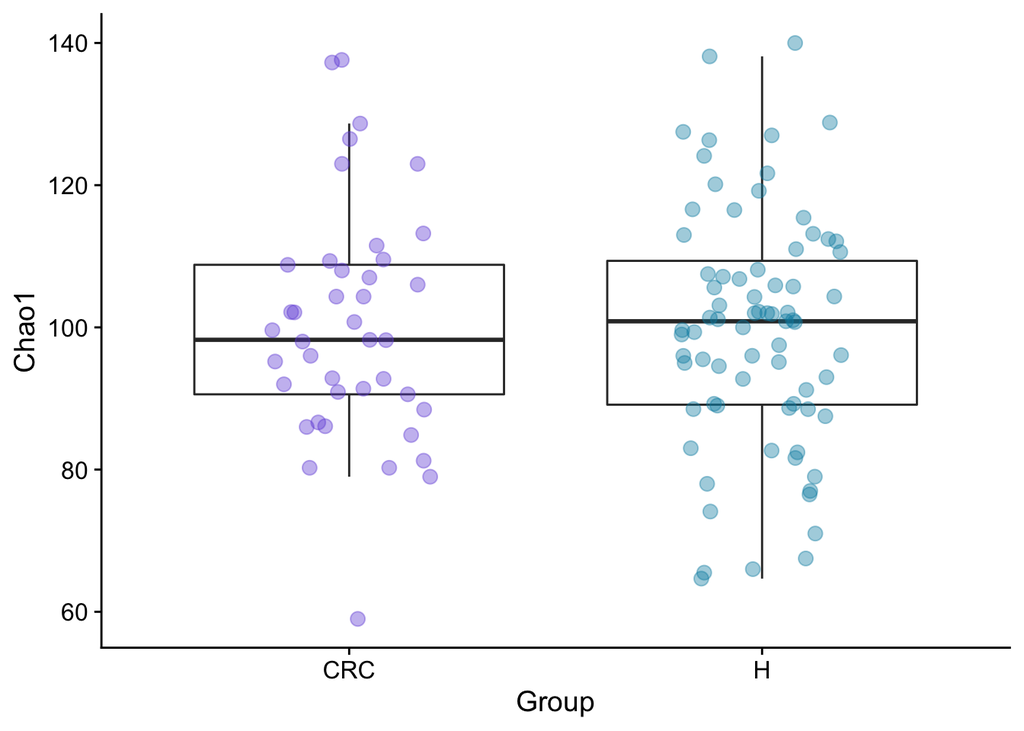

```r
alpha_plot(alpha_values, "Chao1")
```

The function returns a ggplot object, so you can add extra ggplot arguments to it!

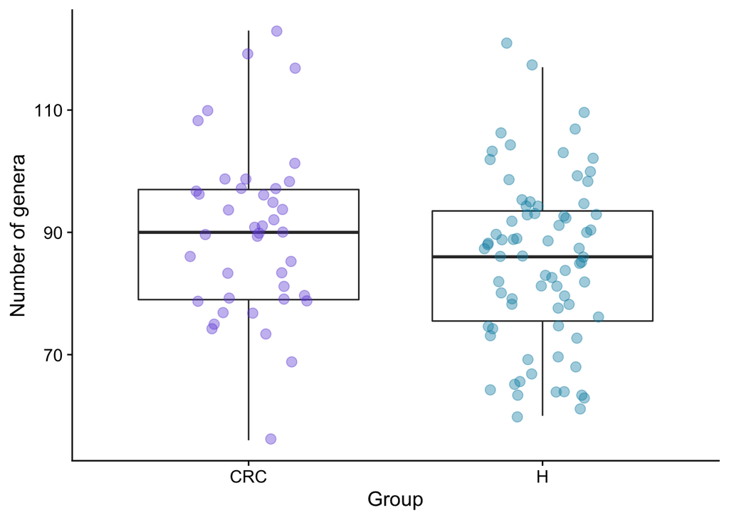

```r
alpha_plot(alpha_values, "Num_genera") + labs(y = "Number of genera")
```

Now, do a statistical test of whether there is a difference in alpha diversity between the two groups.

```r
wilcox.test(alpha_values$Shannon[alpha_values$comparison == "H"], alpha_values$Shannon[alpha_values$comparison == "CRC"])
```

```
##
##  Wilcoxon rank sum test with continuity correction
##
## data:  alpha_values$Shannon[alpha_values$comparison == "H"] and alpha_values$Shannon[alpha_values$comparison == "CRC"]
## W = 1422, p-value = 0.5066
## alternative hypothesis: true location shift is not equal to 0
```

Add statistical test and its output to the plotting function.

```r
alpha_plot_stat <- function(input_table, metric) {
  # Do Wilcoxon rank sum test
  temp <- as.formula(paste0(metric, " ~ comparison"))
  wilc <- input_table %>% rstatix::wilcox_test(temp)

  # Plot with p-value
  ggplot(input_table, aes_string(x = "comparison", y = metric)) +
    geom_boxplot(outlier.color = NA, lwd = 0.5) +
    theme_cowplot() +
    geom_jitter(size = 3, width = 0.2, alpha = 0.4, aes(color = comparison)) +
    scale_color_manual(values = c("#7153db", "#008eb0")) +
    theme(legend.position = "none") +
    labs(x = "Group") +
    ggpubr::stat_pvalue_manual(wilc,
      label = "p",
      y.position = 1.1 * max(alpha_values[, metric])
    )
}
```

Try function with one of the alpha metrics.

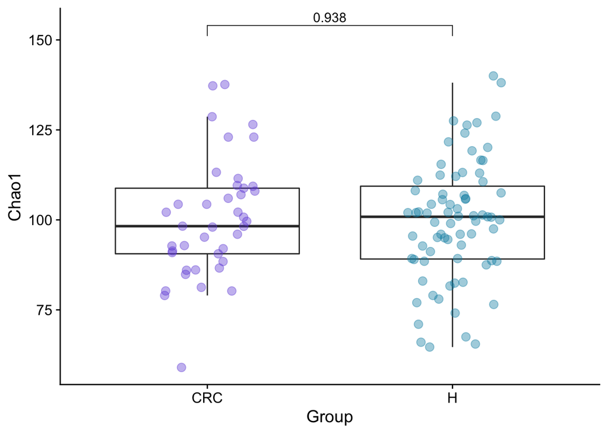

```r
alpha_plot_stat(alpha_values, "Chao1")
```